# Part I - Flights

## Preliminary Wrangling

```python
# import all packages and set plots to be embedded inline
import numpy as np
import pandas as pd
import matplotlib.pyplot as plt
import seaborn as sb
import timeit

%matplotlib inline
```

```python
# open the csv file of fights in Jan and Feb, 2008
df = pd.read_csv('2008.csv')
```

```python
# copy dataset
df_copy = df.copy()
```

```python
# check whether datatype, values are correct and non-null
df.info()
```

```
<class 'pandas.core.frame.DataFrame'>
RangeIndex: 321755 entries, 0 to 321754
Data columns (total 29 columns):
Year                 321755 non-null int64
Month                321754 non-null float64
DayofMonth           321754 non-null float64
DayOfWeek            321754 non-null float64
DepTime              312532 non-null float64
CRSDepTime           321754 non-null float64
ArrTime              311874 non-null float64
CRSArrTime           321754 non-null float64
UniqueCarrier        321754 non-null object
FlightNum            321754 non-null float64
TailNum              317497 non-null object
ActualElapsedTime    311874 non-null float64
CRSElapsedTime       321754 non-null float64
AirTime              311874 non-null float64
ArrDelay             311874 non-null float64
DepDelay             312532 non-null float64
Origin               321754 non-null object
Dest                 321754 non-null object
Distance             321754 non-null float64
TaxiIn               311874 non-null float64
TaxiOut              312532 non-null float64
Cancelled            321754 non-null float64
CancellationCode     9222 non-null object
Diverted             321754 non-null float64
CarrierDelay         78290 non-null float64
WeatherDelay         78290 non-null float64
NASDelay             78290 non-null float64
SecurityDelay        78290 non-null float64
LateAircraftDelay    78290 non-null float64
dtypes: float64(23), int64(1), object(5)
memory usage: 71.2+ MB
```

```python
#delete rows with no data of time depart, arrive and elapsed
df.drop(df[df.DepTime.isnull()].index, inplace=True)
df.drop(df[df.ActualElapsedTime.isnull()].index, inplace=True)
df.drop(df[df.CRSElapsedTime.isnull()].index, inplace=True)
```

```python
# test to make sure the column has no null value
df.ActualElapsedTime.isnull().value_counts()
```

```
False    311874
Name: ActualElapsedTime, dtype: int64
```

```python
# check for datatype and some information of the project
df.info()
```

```
<class 'pandas.core.frame.DataFrame'>
Int64Index: 311874 entries, 0 to 321753
Data columns (total 29 columns):
Year                 311874 non-null int64
Month                311874 non-null float64
DayofMonth           311874 non-null float64
DayOfWeek            311874 non-null float64
DepTime              311874 non-null float64
CRSDepTime           311874 non-null float64
ArrTime              311874 non-null float64
CRSArrTime           311874 non-null float64
UniqueCarrier        311874 non-null object
FlightNum            311874 non-null float64
TailNum              311874 non-null object
ActualElapsedTime    311874 non-null float64
CRSElapsedTime       311874 non-null float64
AirTime              311874 non-null float64
ArrDelay             311874 non-null float64
DepDelay             311874 non-null float64
Origin               311874 non-null object
Dest                 311874 non-null object
Distance             311874 non-null float64
TaxiIn               311874 non-null float64
TaxiOut              311874 non-null float64
Cancelled            311874 non-null float64
CancellationCode     0 non-null object
Diverted             311874 non-null float64
CarrierDelay         78290 non-null float64
WeatherDelay         78290 non-null float64
NASDelay             78290 non-null float64
SecurityDelay        78290 non-null float64
LateAircraftDelay    78290 non-null float64
dtypes: float64(23), int64(1), object(5)
memory usage: 71.4+ MB
```

```python
# inspect the shape of the dataframe
print(df.shape)
```

```
(311874, 29)
```

```python
# check for result
df.info()
```

```
<class 'pandas.core.frame.DataFrame'>
Int64Index: 311874 entries, 0 to 321753
Data columns (total 29 columns):
Year                 311874 non-null int64
Month                311874 non-null float64
DayofMonth           311874 non-null float64
DayOfWeek            311874 non-null float64
DepTime              311874 non-null float64
CRSDepTime           311874 non-null float64
ArrTime              311874 non-null float64
CRSArrTime           311874 non-null float64
UniqueCarrier        311874 non-null object
FlightNum            311874 non-null float64
TailNum              311874 non-null object
ActualElapsedTime    311874 non-null float64
CRSElapsedTime       311874 non-null float64
AirTime              311874 non-null float64
ArrDelay             311874 non-null float64
DepDelay             311874 non-null float64
Origin               311874 non-null object
Dest                 311874 non-null object
Distance             311874 non-null float64
TaxiIn               311874 non-null float64
TaxiOut              311874 non-null float64
Cancelled            311874 non-null float64
CancellationCode     0 non-null object
Diverted             311874 non-null float64
CarrierDelay         78290 non-null float64
WeatherDelay         78290 non-null float64
NASDelay             78290 non-null float64
SecurityDelay        78290 non-null float64
LateAircraftDelay    78290 non-null float64
dtypes: float64(23), int64(1), object(5)
memory usage: 71.4+ MB
```

```python
# descriptive statistics for numeric variables
df.describe()
```

|  | Year | Month | DayofMonth | DayOfWeek | DepTime | CRSDepTime | ArrTime | CRSArrTime | FlightNum | ActualElapsedTime | ... | Distance | TaxiIn | TaxiOut | Cancelled | Diverted | CarrierDelay | WeatherDelay | NASDelay | SecurityDelay | LateAircraftDelay |
| --- | --- | --- | --- | --- | --- | --- | --- | --- | --- | --- | --- | --- | --- | --- | --- | --- | --- | --- | --- | --- | --- |
| count | 311874.0 | 311874.0 | 311874.000000 | 311874.000000 | 311874.000000 | 311874.000000 | 311874.000000 | 311874.000000 | 311874.000000 | 311874.000000 | ... | 311874.000000 | 311874.000000 | 311874.000000 | 311874.0 | 311874.0 | 78290.000000 | 78290.000000 | 78290.000000 | 78290.000000 | 78290.000000 |
| mean | 2008.0 | 1.0 | 16.358206 | 3.837922 | 1349.326545 | 1337.032827 | 1491.252438 | 1497.932373 | 2447.751865 | 120.174609 | ... | 669.367581 | 6.170284 | 15.987383 | 0.0 | 0.0 | 15.431102 | 3.172449 | 15.214919 | 0.113207 | 23.609299 |
| std | 0.0 | 0.0 | 8.889953 | 1.919247 | 476.045697 | 461.543612 | 502.338561 | 480.472009 | 2085.648643 | 66.445664 | ... | 528.525223 | 4.435863 | 10.854475 | 0.0 | 0.0 | 35.391100 | 19.699258 | 34.212159 | 1.905070 | 40.943782 |
| min | 2008.0 | 1.0 | 1.000000 | 1.000000 | 1.000000 | 25.000000 | 1.000000 | 1.000000 | 1.000000 | 16.000000 | ... | 24.000000 | 0.000000 | 0.000000 | 0.0 | 0.0 | 0.000000 | 0.000000 | 0.000000 | 0.000000 | 0.000000 |
| 25% | 2008.0 | 1.0 | 9.000000 | 2.000000 | 940.000000 | 935.000000 | 1112.000000 | 1115.000000 | 768.000000 | 74.000000 | ... | 314.000000 | 4.000000 | 10.000000 | 0.0 | 0.0 | 0.000000 | 0.000000 | 0.000000 | 0.000000 | 0.000000 |
| 50% | 2008.0 | 1.0 | 17.000000 | 4.000000 | 1338.000000 | 1325.000000 | 1520.000000 | 1520.000000 | 1768.000000 | 102.000000 | ... | 508.000000 | 5.000000 | 13.000000 | 0.0 | 0.0 | 0.000000 | 0.000000 | 0.000000 | 0.000000 | 2.000000 |
| 75% | 2008.0 | 1.0 | 24.000000 | 5.000000 | 1740.000000 | 1725.000000 | 1914.000000 | 1909.000000 | 3655.750000 | 145.000000 | ... | 857.000000 | 7.000000 | 19.000000 | 0.0 | 0.0 | 16.000000 | 0.000000 | 17.000000 | 0.000000 | 30.000000 |
| max | 2008.0 | 1.0 | 31.000000 | 7.000000 | 2400.000000 | 2359.000000 | 2400.000000 | 2359.000000 | 7829.000000 | 693.000000 | ... | 4502.000000 | 213.000000 | 383.000000 | 0.0 | 0.0 | 1032.000000 | 587.000000 | 569.000000 | 136.000000 | 799.000000 |

8 rows × 24 columns

### What is/are the main feature(s) of interest in your dataset?

> Actually this is my first time working with data relating to airlines. I found it intesting and eagered to explore what reason most impact the time compliance of the flights and what the maximum delayed time is within the time provided.

### What features in the dataset do you think will help support your investigation into your feature(s) of interest?

> I have to say that the data is quite clean and consolidated, almost columns in the dataset do play a specific role in my analysis and in my interest point as well. However, columns containing time information like departure_time, arrive_time, elapsed_time and 5 columns of delaying reasons are expected to help me investigate my features of interest.

## Univariate Exploration

[output not shown]

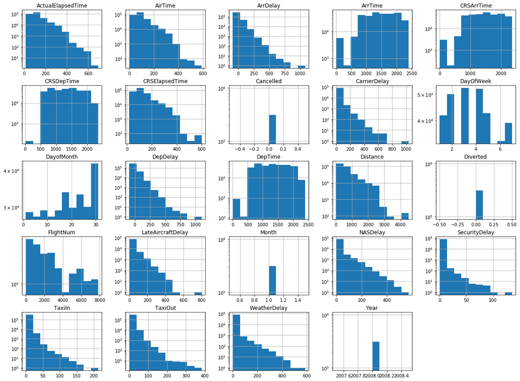

```python
# have a look at histogram of the dataset
df.hist(figsize=(20, 15), log=True)
```

# AirTime

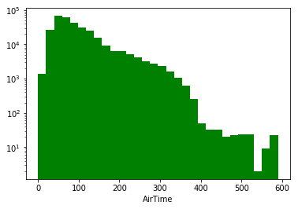

```python
# chart on airTime of flights
plt.hist(data=df, x="AirTime", bins=30, log=True, color='g')
plt.xlabel("AirTime");
```

> I used log scale to have a closer and clearer look on the distribution of the airtime. The graph shows that most flights have the time flying of approximately 60 mins and the air time of more than 500 mins is not too much.

# Departure Delay

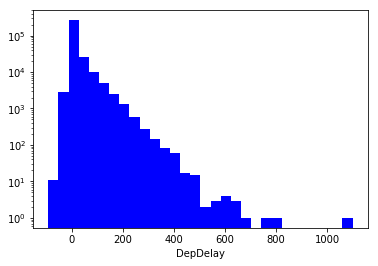

```python
# chart on airTime of flights
plt.hist(data=df, x="DepDelay", bins=30, log=True, color='blue')
plt.xlabel("DepDelay");
```

> The highest time depayed was more than 1000 mins and almost delayed flights in time or an hour late. Howerver, we can see the negative value in the chart for late time of departure and it quite weird here. Can the airline change timeline and depart ealier than schedule? Let's see what it is.

```python
# flights that have DepTime < 0
df[df.DepDelay < 0].sample(10)
```

|  | Year | Month | DayofMonth | DayOfWeek | DepTime | CRSDepTime | ArrTime | CRSArrTime | UniqueCarrier | FlightNum | ... | TaxiIn | TaxiOut | Cancelled | CancellationCode | Diverted | CarrierDelay | WeatherDelay | NASDelay | SecurityDelay | LateAircraftDelay |
| --- | --- | --- | --- | --- | --- | --- | --- | --- | --- | --- | --- | --- | --- | --- | --- | --- | --- | --- | --- | --- | --- |
| 232917 | 2008 | 1.0 | 13.0 | 7.0 | 624.0 | 630.0 | 713.0 | 738.0 | UA | 497.0 | ... | 5.0 | 8.0 | 0.0 | NaN | 0.0 | NaN | NaN | NaN | NaN | NaN |
| 22227 | 2008 | 1.0 | 9.0 | 3.0 | 753.0 | 755.0 | 859.0 | 920.0 | WN | 3431.0 | ... | 6.0 | 6.0 | 0.0 | NaN | 0.0 | NaN | NaN | NaN | NaN | NaN |
| 121863 | 2008 | 1.0 | 22.0 | 2.0 | 1355.0 | 1400.0 | 1608.0 | 1559.0 | XE | 2401.0 | ... | 8.0 | 21.0 | 0.0 | NaN | 0.0 | NaN | NaN | NaN | NaN | NaN |
| 218236 | 2008 | 1.0 | 31.0 | 4.0 | 748.0 | 800.0 | 847.0 | 844.0 | OO | 6688.0 | ... | 26.0 | 11.0 | 0.0 | NaN | 0.0 | NaN | NaN | NaN | NaN | NaN |
| 77861 | 2008 | 1.0 | 27.0 | 7.0 | 1242.0 | 1245.0 | 1247.0 | 1255.0 | WN | 2545.0 | ... | 5.0 | 8.0 | 0.0 | NaN | 0.0 | NaN | NaN | NaN | NaN | NaN |
| 8461 | 2008 | 1.0 | 5.0 | 6.0 | 718.0 | 720.0 | 828.0 | 835.0 | WN | 654.0 | ... | 4.0 | 7.0 | 0.0 | NaN | 0.0 | NaN | NaN | NaN | NaN | NaN |
| 130785 | 2008 | 1.0 | 3.0 | 4.0 | 551.0 | 600.0 | 701.0 | 728.0 | YV | 7106.0 | ... | 8.0 | 11.0 | 0.0 | NaN | 0.0 | NaN | NaN | NaN | NaN | NaN |
| 288185 | 2008 | 1.0 | 26.0 | 6.0 | 1038.0 | 1040.0 | 1151.0 | 1211.0 | US | 1523.0 | ... | 5.0 | 9.0 | 0.0 | NaN | 0.0 | NaN | NaN | NaN | NaN | NaN |
| 143211 | 2008 | 1.0 | 20.0 | 7.0 | 1944.0 | 1946.0 | 2050.0 | 2049.0 | YV | 2789.0 | ... | 6.0 | 13.0 | 0.0 | NaN | 0.0 | NaN | NaN | NaN | NaN | NaN |
| 148445 | 2008 | 1.0 | 27.0 | 7.0 | 1722.0 | 1728.0 | 2000.0 | 2010.0 | YV | 7231.0 | ... | 7.0 | 8.0 | 0.0 | NaN | 0.0 | NaN | NaN | NaN | NaN | NaN |

10 rows × 29 columns

# Distance

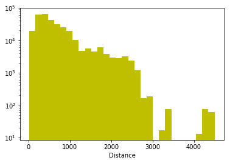

```python
# chart on airTime of flights
plt.hist(data=df, x="Distance", bins=30, log=True, color='y')
plt.xlabel("Distance");
```

> At first, the data makes sense since there was no negative distance. The longest distance of flights was about 4500 km. Let's see where it is.

```python
# flights that have distance > 4500 km
df2=df[df.Distance > 4500]
df2.Origin.value_counts()
```

```
ATL    31
HNL    30
Name: Origin, dtype: int64
```

# Arrive Delay

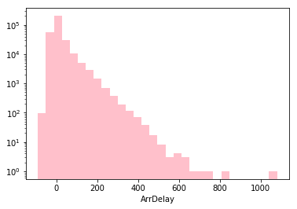

```python
# chart on airTime of flights
plt.hist(data=df, x="ArrDelay", bins=30, log=True, color='pink')
plt.xlabel("ArrDelay");
```

# Delay reasons: 5 main reasons as in the dataset

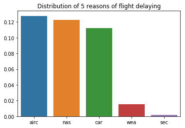

```python
# let's see the occcurance of 5 delay reasons
a = df[(~df.CarrierDelay.isnull()) & (df.CarrierDelay!=0)].shape[0] / df.shape[0]
b = df[(~df.WeatherDelay.isnull()) & (df.WeatherDelay!=0)].shape[0] / df.shape[0]
c = df[(~df.NASDelay.isnull()) & (df.NASDelay!=0)].shape[0] / df.shape[0]
d = df[(~df.SecurityDelay.isnull()) & (df.SecurityDelay!=0)].shape[0] / df.shape[0]
e = df[(~df.LateAircraftDelay.isnull()) & (df.LateAircraftDelay!=0)].shape[0] / df.shape[0]

delay_reasons = pd.Series([a,b,c,d,e], index=["car","wea","nas","sec","airc"]).sort_values(ascending=False)
sb.barplot(delay_reasons.index, delay_reasons).set(title='Distribution of 5 reasons of flight delaying');
```

### Discuss the distribution(s) of your variable(s) of interest. Were there any unusual points? Did you need to perform any transformations?

> Unsurprisingly, Air craft was the main reason makes flights delay. I thought negative values for arrived and departed time was unusual at first, but in reality, it's not an issue since flights' schedule can be changed.

### Of the features you investigated, were there any unusual distributions? Did you perform any operations on the data to tidy, adjust, or change the form of the data? If so, why did you do this?

> Yeah I did drop rows with null depart time and arrive time since these 2 columns play an important part in my analysis.

## Bivariate Exploration

> In this section, investigate relationships between pairs of variables in your data. Make sure the variables that you cover here have been introduced in some fashion in the previous section (univariate exploration).

# Distance vs AirTime

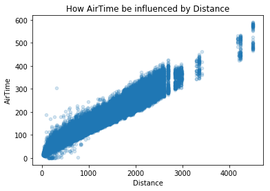

```python
def scatterplot(df, x, y, size, title, alpha):
    plt.scatter(data=df, x=x, y=y, s=size, alpha=alpha)
    plt.title(title)
    plt.xlabel(x)
    plt.ylabel(y)
    plt.show()

scatterplot(df, "Distance", "AirTime", 20, 'How AirTime be influenced by Distance', 0.2)
```

> the data is quite reliable since the trend goes up, it means the longer the distance was, the longer time flights took.

```python
# double check whether any data with distance < 0
df[df.Distance < 0]
```

|  | Year | Month | DayofMonth | DayOfWeek | DepTime | CRSDepTime | ArrTime | CRSArrTime | UniqueCarrier | FlightNum | ... | TaxiIn | TaxiOut | Cancelled | CancellationCode | Diverted | CarrierDelay | WeatherDelay | NASDelay | SecurityDelay | LateAircraftDelay |
| --- | --- | --- | --- | --- | --- | --- | --- | --- | --- | --- | --- | --- | --- | --- | --- | --- | --- | --- | --- | --- | --- |

0 rows × 29 columns

```python
# the maximum distance is
df.Distance.max()
```

```
4502.0
```

```python
df[df.Distance == 4502].sample(10)
```

|  | Year | Month | DayofMonth | DayOfWeek | DepTime | CRSDepTime | ArrTime | CRSArrTime | UniqueCarrier | FlightNum | ... | TaxiIn | TaxiOut | Cancelled | CancellationCode | Diverted | CarrierDelay | WeatherDelay | NASDelay | SecurityDelay | LateAircraftDelay |
| --- | --- | --- | --- | --- | --- | --- | --- | --- | --- | --- | --- | --- | --- | --- | --- | --- | --- | --- | --- | --- | --- |
| 311524 | 2008 | 1.0 | 22.0 | 2.0 | 1625.0 | 1635.0 | 534.0 | 607.0 | DL | 1282.0 | ... | 4.0 | 13.0 | 0.0 | NaN | 0.0 | NaN | NaN | NaN | NaN | NaN |
| 316487 | 2008 | 1.0 | 26.0 | 6.0 | 958.0 | 1005.0 | 1503.0 | 1505.0 | DL | 1273.0 | ... | 5.0 | 18.0 | 0.0 | NaN | 0.0 | NaN | NaN | NaN | NaN | NaN |
| 320185 | 2008 | 1.0 | 29.0 | 2.0 | 1656.0 | 1635.0 | 630.0 | 607.0 | DL | 1282.0 | ... | 8.0 | 31.0 | 0.0 | NaN | 0.0 | 21.0 | 0.0 | 2.0 | 0.0 | 0.0 |
| 311183 | 2008 | 1.0 | 22.0 | 2.0 | 1852.0 | 1900.0 | 807.0 | 844.0 | DL | 850.0 | ... | 7.0 | 10.0 | 0.0 | NaN | 0.0 | NaN | NaN | NaN | NaN | NaN |
| 306491 | 2008 | 1.0 | 18.0 | 5.0 | 1632.0 | 1616.0 | 2133.0 | 2113.0 | DL | 851.0 | ... | 8.0 | 25.0 | 0.0 | NaN | 0.0 | 16.0 | 0.0 | 4.0 | 0.0 | 0.0 |
| 315333 | 2008 | 1.0 | 25.0 | 5.0 | 1630.0 | 1635.0 | 547.0 | 607.0 | DL | 1282.0 | ... | 10.0 | 16.0 | 0.0 | NaN | 0.0 | NaN | NaN | NaN | NaN | NaN |
| 312413 | 2008 | 1.0 | 23.0 | 3.0 | 1850.0 | 1900.0 | 806.0 | 844.0 | DL | 850.0 | ... | 7.0 | 13.0 | 0.0 | NaN | 0.0 | NaN | NaN | NaN | NaN | NaN |
| 317649 | 2008 | 1.0 | 27.0 | 7.0 | 1001.0 | 1005.0 | 1524.0 | 1505.0 | DL | 1273.0 | ... | 6.0 | 34.0 | 0.0 | NaN | 0.0 | 0.0 | 0.0 | 19.0 | 0.0 | 0.0 |
| 318562 | 2008 | 1.0 | 28.0 | 1.0 | 1614.0 | 1616.0 | 2115.0 | 2113.0 | DL | 851.0 | ... | 8.0 | 17.0 | 0.0 | NaN | 0.0 | NaN | NaN | NaN | NaN | NaN |
| 306490 | 2008 | 1.0 | 18.0 | 5.0 | 1855.0 | 1900.0 | 850.0 | 844.0 | DL | 850.0 | ... | 8.0 | 22.0 | 0.0 | NaN | 0.0 | NaN | NaN | NaN | NaN | NaN |

10 rows × 29 columns

# DepDelay vs ArrDelay

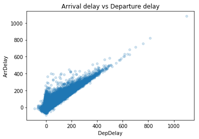

```python
scatterplot(df, "DepDelay", "ArrDelay", 20, 'Arrival delay vs Departure delay', 0.2)
```

> It makes sense because if your flight departed late then the time arrived will be delay also.

# Distance vs ArrDelay

> Will distance impact arrival time?

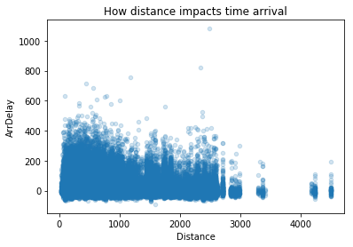

```python
scatterplot(df, "Distance", "ArrDelay", 20, 'How distance impacts time arrival', 0.2)
```

# Distance vs DepDelay

> Will distance impact departure time?

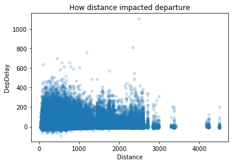

```python
scatterplot(df, "Distance", "DepDelay", 20, 'How distance impacted departure', 0.2)
```

> The graphs show that there is no relationship between distance and Arrival or Departure delay.

# Distance vs 5 delay reasons

> Let's create a dummy df with 4 columns: delay_reason, delay_time, ArrDelay, DepDelay

```python
dummy2 = pd.DataFrame()
delay_reason = ["NASDelay","LateAircraftDelay","CarrierDelay","WeatherDelay", "SecurityDelay"]

for type in delay_reason:
    dum = pd.DataFrame()
    dum["Time"] = df[(df[type] != 0) & (~df[type].isnull())][type]
    dum["DepDelay"] = df[(df[type] != 0) & (~df[type].isnull())]["DepDelay"]
    dum["ArrDelay"] = df[(df[type] != 0) & (~df[type].isnull())]["ArrDelay"]
    dum["Distance"] = df[(df[type] != 0) & (~df[type].isnull())]["Distance"]
    dum["Type"] = type
    dummy2 = dummy2.append(dum)
```

```python
dummy2.head()
```

|  | Time | DepDelay | ArrDelay | Distance | Type |
| --- | --- | --- | --- | --- | --- |
| 11 | 3.0 | 53.0 | 56.0 | 937.0 | NASDelay |
| 12 | 20.0 | 19.0 | 39.0 | 937.0 | NASDelay |
| 26 | 8.0 | 55.0 | 63.0 | 1642.0 | NASDelay |
| 28 | 6.0 | 49.0 | 55.0 | 419.0 | NASDelay |
| 30 | 3.0 | 20.0 | 23.0 | 419.0 | NASDelay |

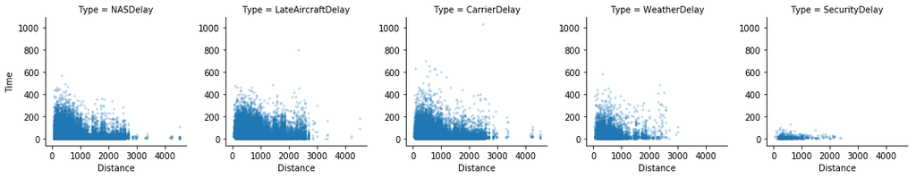

```python
# Relationship between distance and 4 delay reasons
g = sb.FacetGrid(data=dummy2, col="Type")
g.map(plt.scatter, "Distance", "Time", alpha = 0.2, s=4);
```

# ArrDelay vs 5 delay reasons

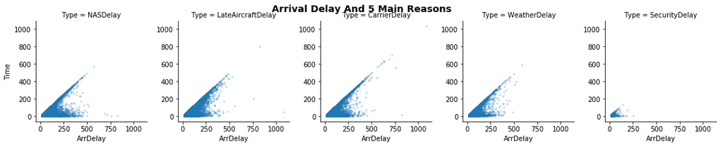

```python
# Relationship between distance and 4 delay reasons
g = sb.FacetGrid(data=dummy2, col="Type")
g.map(plt.scatter, "ArrDelay", "Time", alpha = 0.2, s=4)
plt.suptitle("Arrival delay and 5 main reasons".title(), y = 1, fontsize = 14, weight = "bold");
```

> The result is predictable as the trend goes up, for all 5 reasons of flight delay, the longer the time a flight late in arrive, the higher time it recorded in each Delay reason.

# DepDelay vs 5 delay reasons

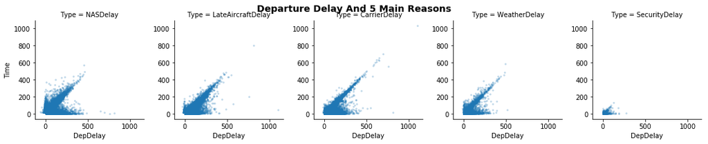

```python
# Relationship between distance and 5 delay reasons
g = sb.FacetGrid(data=dummy2, col="Type")
g.map(plt.scatter, "DepDelay", "Time", alpha = 0.2, s=4)
plt.suptitle("Departure delay and 5 main reasons".title(), y = 1, fontsize = 14, weight = "bold");
```

### Talk about some of the relationships you observed in this part of the investigation. How did the feature(s) of interest vary with other features in the dataset?

> Besides the relationship between departure delay and arriving delay, I found that there was almost no any relationship between distance and time delay. The time delay is mainly affected by 5 reasons, in which 3 main reason appear in the time inspected was NAS, LateAirCraft and Carrier.

### Did you observe any interesting relationships between the other features (not the main feature(s) of interest)?

> The relationship between distance and airtime was not so impressive but it still a thing to think of. Moreover, security didn't contribute much in delaying flights and that makes me surprise since I always think it will appear in high rate.

## Multivariate Exploration

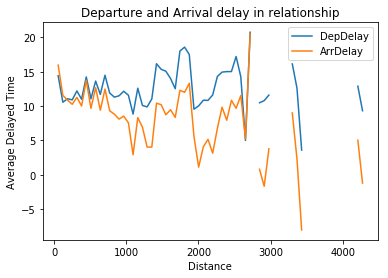

```python
for multi in ["DepDelay","ArrDelay"]:
    bin_edge = np.linspace(df.Distance.min(), df.Distance.max(), 70)
    bin_center = (bin_edge[:-1] + bin_edge[1:]) / 2
    data_bin = pd.cut(df.Distance, bin_edge, right = False, include_lowest=True)
    mean = df[multi].groupby(data_bin).mean()
    plt.errorbar(x=bin_center,y=mean)
plt.xlabel("Distance")
plt.ylabel("Average Delayed Time")
plt.title("Departure and Arrival delay in relationship")
plt.legend();
```

```python
dummy2.DepDelay.value_counts()
```

```
 0.0      2504
 20.0     2100
 25.0     1943
 15.0     1887
 30.0     1779
 10.0     1756
 22.0     1747
 16.0     1735
 26.0     1722
 17.0     1688
 24.0     1659
 28.0     1649
 27.0     1647
 21.0     1639
 14.0     1603
 18.0     1592
 23.0     1584
 19.0     1574
 29.0     1555
 35.0     1540
 33.0     1470
 13.0     1417
 32.0     1390
 31.0     1379
 12.0     1372
 11.0     1306
 34.0     1282
 40.0     1268
 36.0     1267
 38.0     1237
          ...
 587.0       1
 459.0       1
 425.0       1
 444.0       1
-44.0        1
 371.0       1
 496.0       1
 329.0       1
 486.0       1
 456.0       1
-36.0        1
-27.0        1
 653.0       1
 390.0       1
 301.0       1
 364.0       1
 483.0       1
 638.0       1
-23.0        1
 468.0       1
 472.0       1
 400.0       1
 580.0       1
-33.0        1
 480.0       1
 464.0       1
 391.0       1
 384.0       1
-53.0        1
-29.0        1
Name: DepDelay, Length: 481, dtype: int64
```

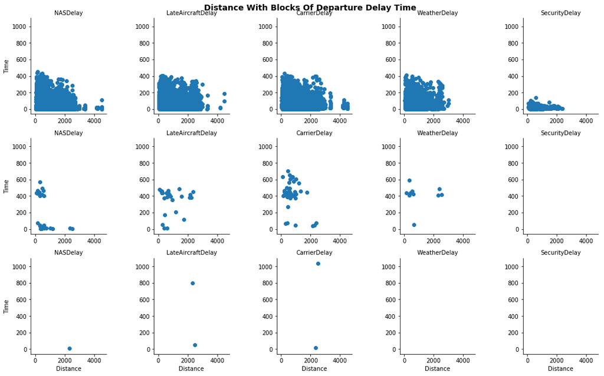

```python
# divide ArrDelay in blocks and then visualize delay time of each delay reasons by distance in each block
bin_edge = np.arange(0,1600,400)
dummy2["DepDelay"] = pd.cut(dummy2.DepDelay, bin_edge, right=False)
g = sb.FacetGrid(data=dummy2, row="DepDelay", col="Type" )
g.map(plt.scatter, "Distance", "Time")
plt.suptitle("Distance with blocks of departure delay time".title(), y = 1, fontsize = 14, weight = "bold")
g.set_titles('{col_name}');
```

### Talk about some of the relationships you observed in this part of the investigation. Were there features that strengthened each other in terms of looking at your feature(s) of interest?

> The multivariate exploration still showed that distance have no relationship with delay time. However, the second visual indicated the relationship between Departure delay time and 3 main reasons of the flight delay (NAS, LateAircraft and Carrier) and the longest time of delaying was from carrier.

### Were there any interesting or surprising interactions between features?

> Actually nothing strange here since almost facts have showed in previous explorations.